# Example4

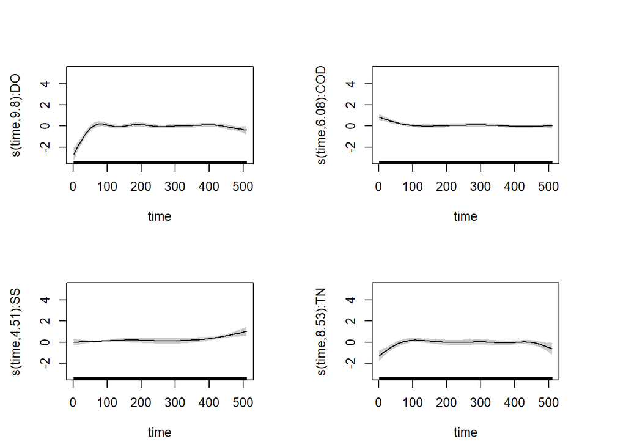

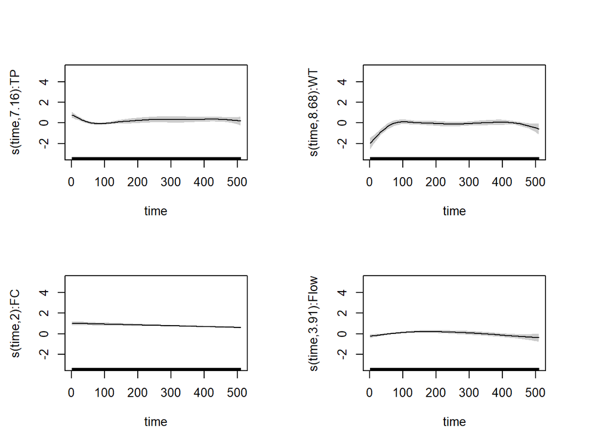

```r
par(mfrow=c(1,1))
vc5 <- gam(TC~s(time,by=DO)+s(time,by=COD)+s(time,by=SS)+s(time,by=TN)+s(time,by=TP)+s(time,by=WT)+s(time,by=FC)+s(time,by=Flow),data=ex1_scale) # vc4 모형에서 유의하지 않다고 나온 변수 제외
par(mfrow=c(2,2))
plot(vc5,residuals=TRUE,pch=1,shade=TRUE,seWithMean=TRUE,shift=coef(vc5)[1])
```

```r
par(mfrow=c(1,1))
summary(vc5) # R-sq.(adj) =  0.76
```

```
##
## Family: gaussian
## Link function: identity
##
## Formula:
## TC ~ s(time, by = DO) + s(time, by = COD) + s(time, by = SS) +
##     s(time, by = TN) + s(time, by = TP) + s(time, by = WT) +
##     s(time, by = FC) + s(time, by = Flow)
##
## Parametric coefficients:
##             Estimate Std. Error t value Pr(>|t|)
## (Intercept)  0.05373    0.04173   1.287    0.199
##
## Approximate significance of smooth terms:
##                edf Ref.df       F  p-value
## s(time):DO   9.801  9.966   9.678  < 2e-16 ***
## s(time):COD  6.084  7.100   4.050 0.000216 ***
## s(time):SS   4.515  5.326   8.455  < 2e-16 ***
## s(time):TN   8.532  9.343   4.344 1.56e-05 ***
## s(time):TP   7.160  8.229   5.244 2.19e-06 ***
## s(time):WT   8.680  9.437   7.787  < 2e-16 ***
## s(time):FC   2.000  2.000 256.750  < 2e-16 ***
## s(time):Flow 3.910  4.592   5.042 0.000477 ***
## ---
## Signif. codes:  0 '***' 0.001 '**' 0.01 '*' 0.05 '.' 0.1 ' ' 1
##
## R-sq.(adj) =   0.76   Deviance explained = 78.4%
## GCV = 0.26677  Scale est. = 0.23974   n = 510
```

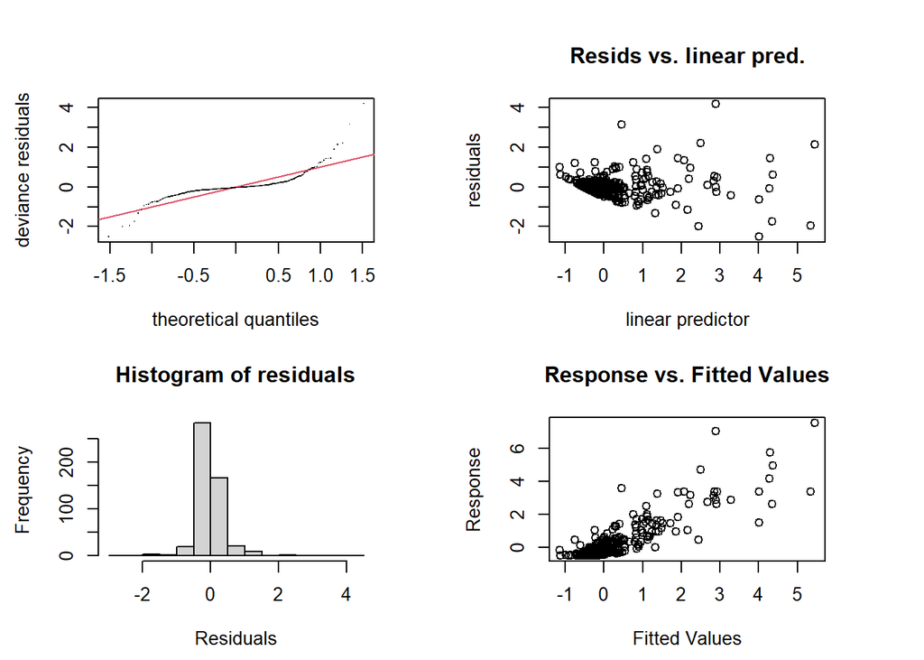

```
##
## Method: GCV   Optimizer: magic
## Smoothing parameter selection converged after 21 iterations.
## The RMS GCV score gradient at convergence was 5.840462e-08 .
## The Hessian was positive definite.
## Model rank =  81 / 81
##
## Basis dimension (k) checking results. Low p-value (k-index<1) may
## indicate that k is too low, especially if edf is close to k'.
##
##                 k'   edf k-index p-value
## s(time):DO   10.00  9.80    1.03    0.80
## s(time):COD  10.00  6.08    1.03    0.73
## s(time):SS   10.00  4.51    1.03    0.68
## s(time):TN   10.00  8.53    1.03    0.80
## s(time):TP   10.00  7.16    1.03    0.77
## s(time):WT   10.00  8.68    1.03    0.78
## s(time):FC   10.00  2.00    1.03    0.75
## s(time):Flow 10.00  3.91    1.03    0.79
```

```r
par(mfrow=c(2,2))
gam.check(vc5)
```

```r
par(mfrow=c(1,1))
```

#### 최종선택된 모형의 설명력 : 62.4%(다중선형회귀모형), 71.5%(일반화가법모형), 76.0%(시간에 따른 계수변화모형)

#### 일반화가법모형이나 시간에 따른 계수변화모형이 다중선형회귀모형보다 설명력이 우수하다는 것을 확실하게 보여주기 위해서는 설명변수들과 확실한 비선형관계가 있다고 여겨지는 변수를 반응변수로 선택하는 것이 좋다고 판단됨.

### Dependent(Response) variable : FC

### Multiple Linear Regression

#### scaling data 사용

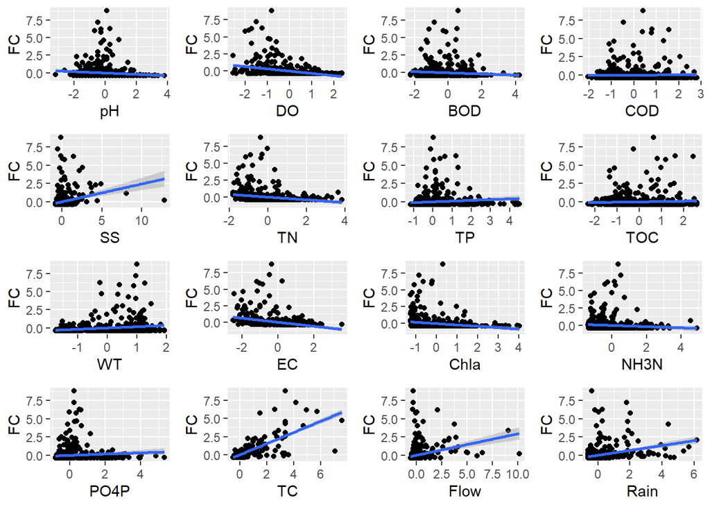

```r
ex1 <- read.csv("C:/Users/HSY/Desktop/광산(2010-2019).csv", sep=",", header=T)
ex1 <- ex1[,-1]
ex1_scale <- scale(ex1)
ex1_scale <- as.data.frame(ex1_scale)
p1 <- ggplot(data=ex1_scale,aes(x=pH,y=FC)) + geom_point() + stat_smooth(method=lm)
p2 <- ggplot(data=ex1_scale,aes(x=DO,y=FC)) + geom_point() + stat_smooth(method=lm)
p3 <- ggplot(data=ex1_scale,aes(x=BOD,y=FC)) + geom_point() + stat_smooth(method=lm)
p4 <- ggplot(data=ex1_scale,aes(x=COD,y=FC)) + geom_point() + stat_smooth(method=lm)
p5 <- ggplot(data=ex1_scale,aes(x=SS,y=FC)) + geom_point() + stat_smooth(method=lm)
p6 <- ggplot(data=ex1_scale,aes(x=TN,y=FC)) + geom_point() + stat_smooth(method=lm)
p7 <- ggplot(data=ex1_scale,aes(x=TP,y=FC)) + geom_point() + stat_smooth(method=lm)
p8 <- ggplot(data=ex1_scale,aes(x=TOC,y=FC)) + geom_point() + stat_smooth(method=lm)
p9 <- ggplot(data=ex1_scale,aes(x=WT,y=FC)) + geom_point() + stat_smooth(method=lm)
p10 <- ggplot(data=ex1_scale,aes(x=EC,y=FC)) + geom_point() + stat_smooth(method=lm)
p11 <- ggplot(data=ex1_scale,aes(x=Chla,y=FC)) + geom_point() + stat_smooth(method=lm)
p12 <- ggplot(data=ex1_scale,aes(x=NH3N,y=FC)) + geom_point() + stat_smooth(method=lm)
p13 <- ggplot(data=ex1_scale,aes(x=PO4P,y=FC)) + geom_point() + stat_smooth(method=lm)
p14 <- ggplot(data=ex1_scale,aes(x=TC,y=FC)) + geom_point() + stat_smooth(method=lm)
p15 <- ggplot(data=ex1_scale,aes(x=Flow,y=FC)) + geom_point() + stat_smooth(method=lm)
p16 <- ggplot(data=ex1_scale,aes(x=Rain,y=FC)) + geom_point() + stat_smooth(method=lm)
grid.arrange(p1,p2,p3,p4,p5,p6,p7,p8,p9,p10,p11,p12,p13,p14,p15,p16,nrow=4,ncol=4)
```

```r
fit <- lm(FC~.,data=ex1_scale)
summary(fit) # Adjusted R-squared:  0.6139
```

```
##
## Call:
## lm(formula = FC ~ ., data = ex1_scale)
##
## Residuals:
##     Min      1Q  Median      3Q     Max
## -4.4910 -0.1353 -0.0129  0.1156  6.1023
##
## Coefficients:
##               Estimate Std. Error t value Pr(>|t|)
## (Intercept)  4.357e-17  2.751e-02   0.000   1.0000
## pH           7.990e-03  3.501e-02   0.228   0.8196
## DO          -1.560e-02  4.911e-02  -0.318   0.7509
## BOD         -1.221e-01  5.262e-02  -2.320   0.0208 *
## COD         -1.071e-01  6.651e-02  -1.611   0.1079
## SS          -2.063e-02  4.349e-02  -0.474   0.6355
## TN          -6.821e-02  1.052e-01  -0.648   0.5171
## TP          -2.906e-02  1.097e-01  -0.265   0.7913
## TOC          1.619e-01  5.911e-02   2.738   0.0064 **
## WT           6.872e-02  5.401e-02   1.272   0.2038
## EC          -6.011e-02  6.807e-02  -0.883   0.3776
## TC           7.396e-01  3.299e-02  22.422   <2e-16 ***
## NH3N         1.425e-01  7.654e-02   1.862   0.0632 .
## PO4P         2.433e-02  1.016e-01   0.240   0.8108
## Chla         5.106e-02  4.704e-02   1.085   0.2783
## Flow         5.901e-02  4.225e-02   1.397   0.1631
## Rain         9.907e-03  4.196e-02   0.236   0.8135
## ---
## Signif. codes:  0 '***' 0.001 '**' 0.01 '*' 0.05 '.' 0.1 ' ' 1
##
## Residual standard error: 0.6214 on 493 degrees of freedom
## Multiple R-squared:  0.626,  Adjusted R-squared:  0.6139
## F-statistic: 51.58 on 16 and 493 DF,  p-value: < 2.2e-16
```

```r
vif(fit) # 다중공선성(multicollinearity) 존재
```

```
##        pH        DO       BOD       COD        SS        TN        TP       TOC
##  1.615449  3.179086  3.650623  5.831814  2.493406 14.596467 15.879041  4.606501
##        WT        EC        TC      NH3N      PO4P      Chla      Flow      Rain
##  3.845338  6.107542  1.434456  7.722407 13.597733  2.917533  2.353458  2.321513
```

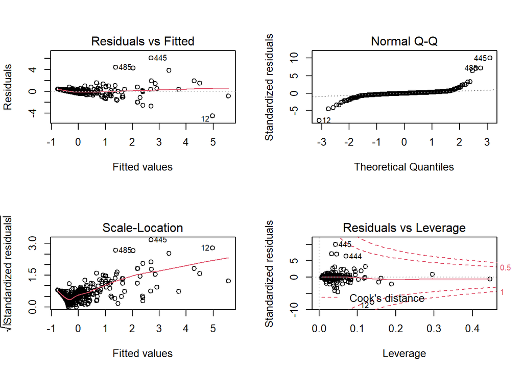

```r
par(mfrow=c(2,2))
plot(fit)
```

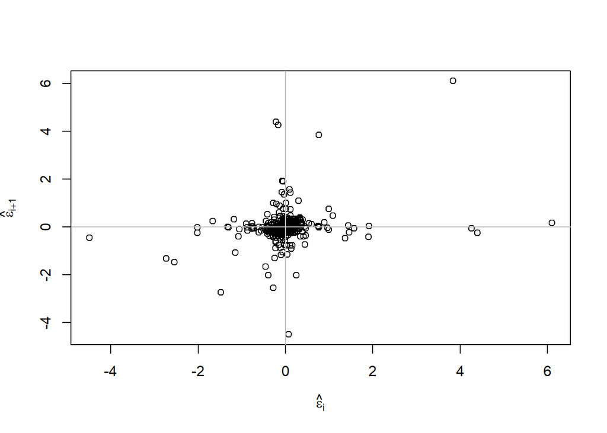

```r
par(mfrow=c(1,1))
n <- length(residuals(fit))
plot(tail(residuals(fit),n-1) ~ head(residuals(fit),n-1), xlab= expression(hat(epsilon)[i]),ylab=expression(hat(epsilon)[i+1]))
abline(h=0,v=0,col=grey(0.75))
```

```r
dwtest(FC~.,data=ex1_scale) # 잔차가 양의 자기상관성을 가지고 있음.
```

```
##
##  Durbin-Watson test
##
## data:  FC ~ .
## DW = 1.5277, p-value = 7.489e-09
## alternative hypothesis: true autocorrelation is greater than 0
```

```r
fit1 <- lm(FC~BOD+TOC+TC,data=ex1_scale) # 모형 fit에서 유의하지 않은 변수를 제외함.
summary(fit1) # Adjusted R-squared:  0.6038
```

```
##
## Call:
## lm(formula = FC ~ BOD + TOC + TC, data = ex1_scale)
##
## Residuals:
##     Min      1Q  Median      3Q     Max
## -4.7616 -0.1127 -0.0172  0.0863  6.2098
##
## Coefficients:
##               Estimate Std. Error t value Pr(>|t|)
## (Intercept)  6.147e-17  2.787e-02   0.000  1.00000
## BOD         -1.565e-01  3.881e-02  -4.032 6.38e-05 ***
## TOC          1.193e-01  3.884e-02   3.073  0.00223 **
## TC           7.631e-01  2.798e-02  27.279  < 2e-16 ***
## ---
## Signif. codes:  0 '***' 0.001 '**' 0.01 '*' 0.05 '.' 0.1 ' ' 1
##
## Residual standard error: 0.6295 on 506 degrees of freedom
## Multiple R-squared:  0.6061, Adjusted R-squared:  0.6038
## F-statistic: 259.6 on 3 and 506 DF,  p-value: < 2.2e-16
```

```r
vif(fit1)
```

```
##      BOD      TOC       TC
## 1.934604 1.937822 1.005394
```

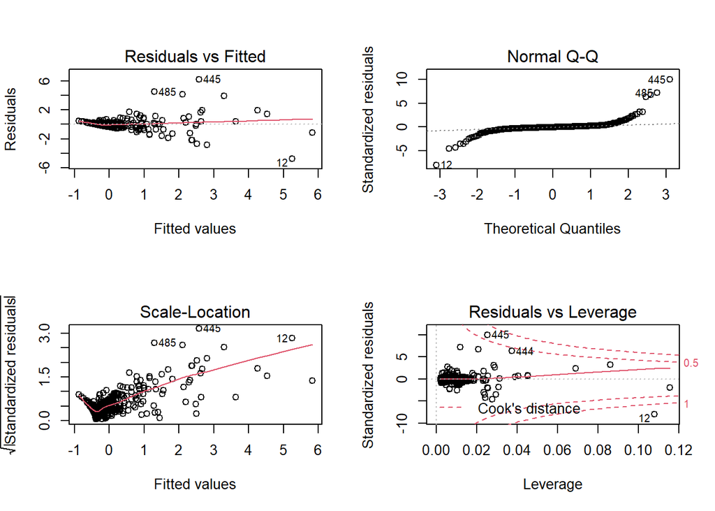

```r
par(mfrow=c(2,2))
plot(fit1)
```

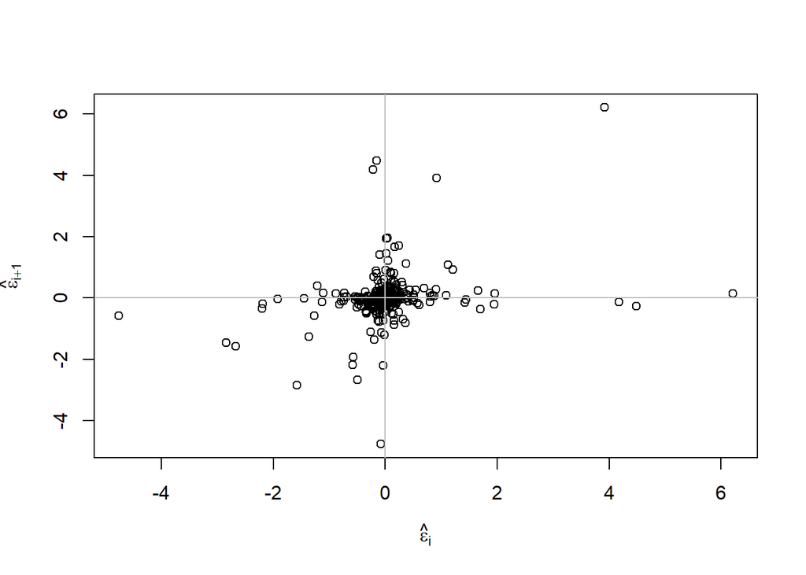

```r
par(mfrow=c(1,1))
n <- length(residuals(fit1))
plot(tail(residuals(fit1),n-1) ~ head(residuals(fit1),n-1), xlab= expression(hat(epsilon)[i]),ylab=expression(hat(epsilon)[i+1]))
abline(h=0,v=0,col=grey(0.75))
```

```r
dwtest(FC~BOD+TOC+TC,data=ex1_scale)
```

```
##
##  Durbin-Watson test
##
## data:  FC ~ BOD + TOC + TC
## DW = 1.444, p-value = 9.848e-11
## alternative hypothesis: true autocorrelation is greater than 0
```

```r
# 다중회귀분석에 대한 기본가정인 잔차(residual)에 대한 정규성, 등분산성, 독립성, 선형성 등을 만족하지 못함.
```

### Generalized Additive Model

#### scaling data 사용

```r
# GAM의 경우 추정되는 계수(coefficients)가 데이터의 개수보다 많으면 적합되지 않음.
m <- gam(FC~s(pH)+s(DO)+s(BOD)+s(COD)+s(SS)+s(TN)+s(TP)+s(TOC)+s(WT)+s(EC)+s(Chla)+s(NH3N)+s(PO4P)+s(TC)+s(Flow)+s(Rain),data=ex1_scale)
ggGam(m)
```

```
##  chr "ggGam(model = m)"
## List of 1
##  $ model: chr "m"
```

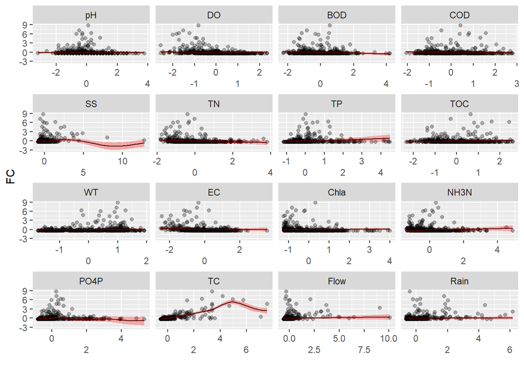

```r
summary(m) # R-sq.(adj) =  0.698
```

```
##
## Family: gaussian
## Link function: identity
##
## Formula:
## FC ~ s(pH) + s(DO) + s(BOD) + s(COD) + s(SS) + s(TN) + s(TP) +
##     s(TOC) + s(WT) + s(EC) + s(Chla) + s(NH3N) + s(PO4P) + s(TC) +
##     s(Flow) + s(Rain)
##
## Parametric coefficients:
##               Estimate Std. Error t value Pr(>|t|)
## (Intercept) -5.364e-14  2.432e-02       0        1
##
## Approximate significance of smooth terms:
##           edf Ref.df      F p-value
## s(pH)   1.606  2.018  0.459 0.62337
## s(DO)   1.815  2.300  0.675 0.47954
## s(BOD)  1.488  1.844  3.569 0.05977 .
## s(COD)  1.000  1.000  0.889 0.34633
## s(SS)   5.585  6.629  2.842 0.01181 *
## s(TN)   1.000  1.000  1.802 0.18007
## s(TP)   2.072  2.693  1.050 0.40695
## s(TOC)  1.000  1.000  2.697 0.10124
## s(WT)   1.000  1.000  0.614 0.43368
## s(EC)   2.267  2.970  1.575 0.18170
## s(Chla) 1.000  1.000  1.187 0.27649
## s(NH3N) 4.423  5.472  3.776 0.00219 **
## s(PO4P) 7.956  8.679  2.927 0.00491 **
## s(TC)   7.809  8.614 68.696 < 2e-16 ***
## s(Flow) 1.000  1.000  0.836 0.36101
## s(Rain) 1.000  1.000  0.154 0.69464
## ---
## Signif. codes:  0 '***' 0.001 '**' 0.01 '*' 0.05 '.' 0.1 ' ' 1
##
## R-sq.(adj) =  0.698   Deviance explained = 72.3%
## GCV = 0.32949  Scale est. = 0.30169   n = 510
```

```r
concurvity(m,full=TRUE) # 공선성 존재
```

```
##                  para     s(pH)     s(DO)    s(BOD)    s(COD)     s(SS)
## worst    7.211521e-19 0.6058025 0.8391587 0.8586499 0.8943836 0.9989212
## observed 7.211521e-19 0.4106371 0.4294040 0.8131803 0.8851802 0.5903206
## estimate 7.211521e-19 0.4769301 0.7125204 0.7576945 0.8316334 0.8153180
##              s(TN)     s(TP)    s(TOC)     s(WT)     s(EC)   s(Chla)   s(NH3N)
## worst    0.9537468 0.9709096 0.8578656 0.8697486 0.9493362 0.8077261 0.9241455
## observed 0.9527107 0.9657302 0.8490992 0.8537248 0.9145040 0.7721170 0.8679842
## estimate 0.9116365 0.9227398 0.7762585 0.8031372 0.8347143 0.6915815 0.8555152
##            s(PO4P)     s(TC)   s(Flow)   s(Rain)
## worst    0.9663907 0.6948236 0.9988835 0.8390453
## observed 0.7096844 0.5078808 0.8201118 0.8024704
## estimate 0.9181951 0.3918816 0.7275608 0.7100177
```

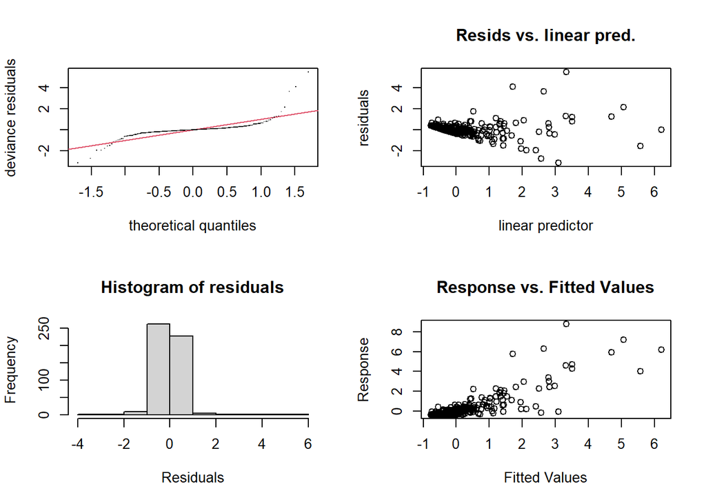

```
##
## Method: GCV   Optimizer: magic
## Smoothing parameter selection converged after 25 iterations.
## The RMS GCV score gradient at convergence was 1.177704e-08 .
## The Hessian was positive definite.
## Model rank =  145 / 145
##
## Basis dimension (k) checking results. Low p-value (k-index<1) may
## indicate that k is too low, especially if edf is close to k'.
##
##           k'  edf k-index p-value
## s(pH)   9.00 1.61    0.91    0.03 *
## s(DO)   9.00 1.81    1.13    0.99
## s(BOD)  9.00 1.49    1.02    0.71
## s(COD)  9.00 1.00    1.07    0.93
## s(SS)   9.00 5.58    1.02    0.63
## s(TN)   9.00 1.00    0.99    0.30
## s(TP)   9.00 2.07    1.00    0.45
## s(TOC)  9.00 1.00    1.04    0.79
## s(WT)   9.00 1.00    0.95    0.11
## s(EC)   9.00 2.27    0.93    0.03 *
## s(Chla) 9.00 1.00    0.99    0.41
## s(NH3N) 9.00 4.42    1.04    0.84
## s(PO4P) 9.00 7.96    1.11    0.99
## s(TC)   9.00 7.81    1.04    0.84
## s(Flow) 9.00 1.00    0.99    0.34
## s(Rain) 9.00 1.00    0.96    0.10
## ---
## Signif. codes:  0 '***' 0.001 '**' 0.01 '*' 0.05 '.' 0.1 ' ' 1
```

```r
par(mfrow=c(2,2))
gam.check(m) # 적합결여 존재 (기저함수 부족)
```

```r
par(mfrow=c(1,1))
m1 <- gam(FC~s(SS)+s(NH3N)+s(PO4P)+s(TC),data=ex1_scale) # 모형 m에서 유의하지 않은 변수를 제외하고 모형구축.
ggGam(m1)
```

```
##  chr "ggGam(model = m1)"
## List of 1
##  $ model: chr "m1"
```

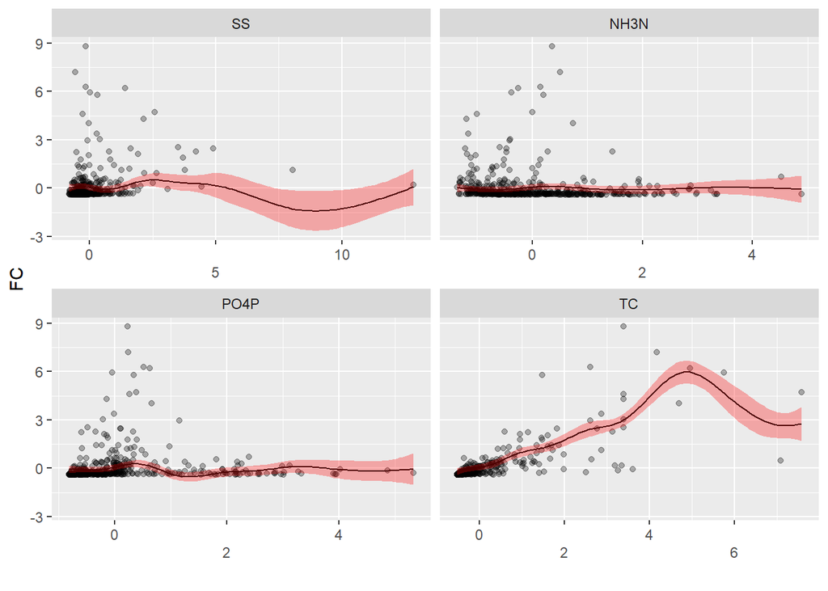

```r
summary(m1) # R-sq.(adj) =  0.681
```

```
##
## Family: gaussian
## Link function: identity
##
## Formula:
## FC ~ s(SS) + s(NH3N) + s(PO4P) + s(TC)
##
## Parametric coefficients:
##              Estimate Std. Error t value Pr(>|t|)
## (Intercept) -1.16e-15   2.50e-02       0        1
##
## Approximate significance of smooth terms:
##           edf Ref.df      F  p-value
## s(SS)   6.570  7.597  2.495 0.017191 *
## s(NH3N) 5.275  6.398  1.517 0.163323
## s(PO4P) 7.937  8.683  3.152 0.000877 ***
## s(TC)   8.440  8.905 80.981  < 2e-16 ***
## ---
## Signif. codes:  0 '***' 0.001 '**' 0.01 '*' 0.05 '.' 0.1 ' ' 1
##
## R-sq.(adj) =  0.681   Deviance explained = 69.9%
## GCV = 0.33824  Scale est. = 0.31886   n = 510
```

```r
concurvity(m1,full=TRUE)
```

```
##                  para     s(SS)    s(NH3N)   s(PO4P)     s(TC)
## worst    7.286937e-22 0.3004542 0.27117994 0.4103558 0.4498524
## observed 7.286937e-22 0.1170043 0.08926315 0.1753854 0.2820442
## estimate 7.286937e-22 0.1376296 0.18551261 0.2420506 0.1806183
```

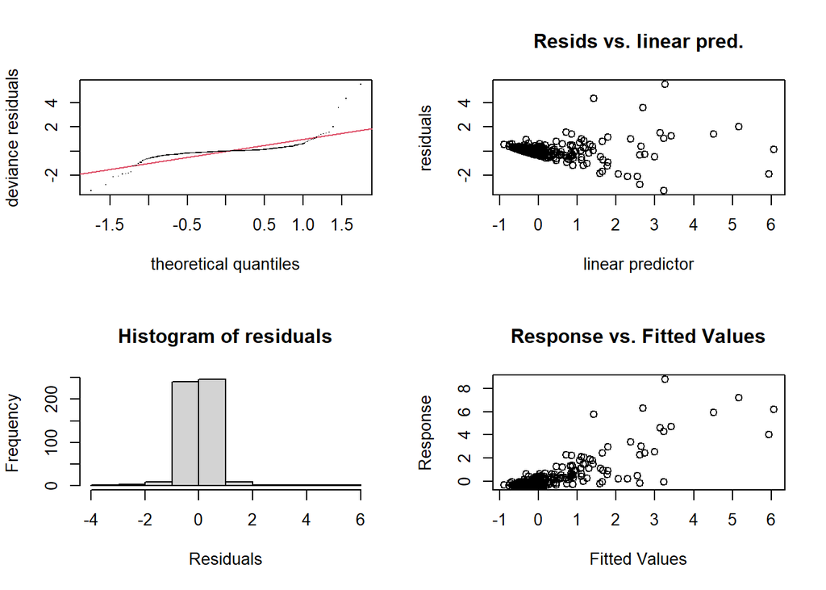

```
##
## Method: GCV   Optimizer: magic
## Smoothing parameter selection converged after 12 iterations.
## The RMS GCV score gradient at convergence was 6.782835e-08 .
## The Hessian was positive definite.
## Model rank =  37 / 37
##
## Basis dimension (k) checking results. Low p-value (k-index<1) may
## indicate that k is too low, especially if edf is close to k'.
##
##           k'  edf k-index p-value
## s(SS)   9.00 6.57    1.02    0.75
## s(NH3N) 9.00 5.27    1.03    0.80
## s(PO4P) 9.00 7.94    1.09    0.96
## s(TC)   9.00 8.44    1.04    0.83
```

```r
par(mfrow=c(2,2))
gam.check(m1)
```

```r
par(mfrow=c(1,1))
m2 <- gam(FC~s(SS)+s(PO4P)+s(TC),data=ex1_scale) # 모형 m1에서 유의하지 않은 변수를 제외하고 모형구축.
ggGam(m2)
```

```
##  chr "ggGam(model = m2)"
## List of 1
##  $ model: chr "m2"
```

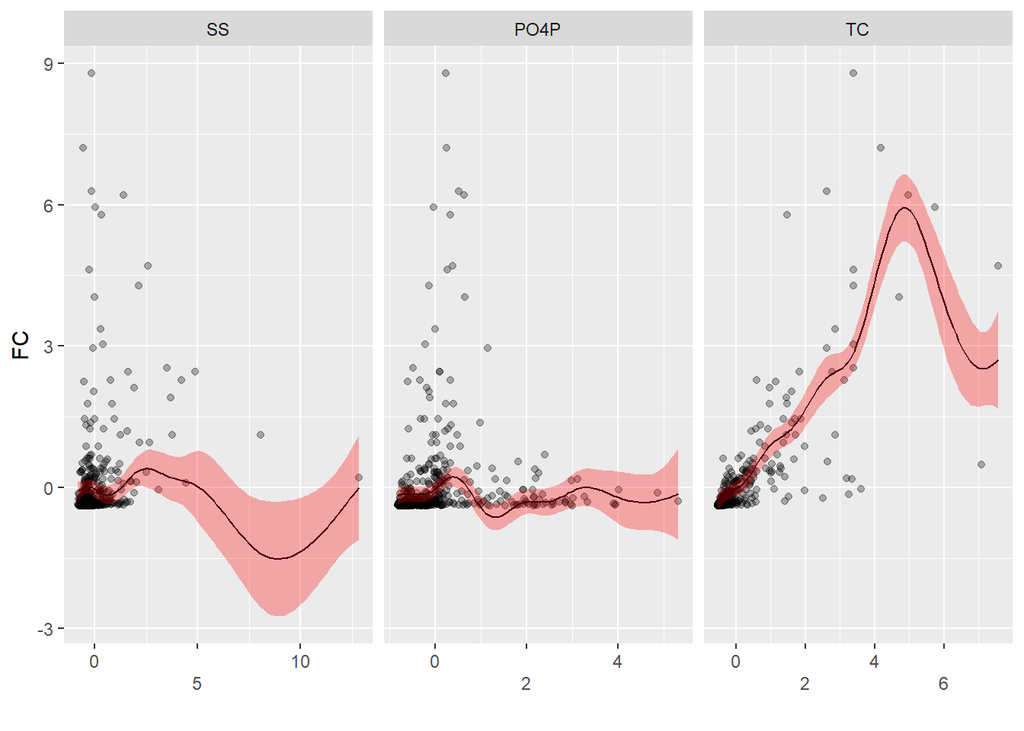

```r
summary(m2) # R-sq.(adj) =  0.677
```

```
##
## Family: gaussian
## Link function: identity
##
## Formula:
## FC ~ s(SS) + s(PO4P) + s(TC)
##
## Parametric coefficients:
##              Estimate Std. Error t value Pr(>|t|)
## (Intercept) 1.503e-16  2.518e-02       0        1
##
## Approximate significance of smooth terms:
##           edf Ref.df      F  p-value
## s(SS)   6.461  7.496  2.303 0.028224 *
## s(PO4P) 8.219  8.821  3.389 0.000383 ***
## s(TC)   8.507  8.926 79.679  < 2e-16 ***
## ---
## Signif. codes:  0 '***' 0.001 '**' 0.01 '*' 0.05 '.' 0.1 ' ' 1
##
## R-sq.(adj) =  0.677   Deviance explained = 69.1%
## GCV = 0.33953  Scale est. = 0.32342   n = 510
```

```r
concurvity(m2,full=TRUE)
```

```
##                  para     s(SS)   s(PO4P)     s(TC)
## worst    2.775188e-22 0.2837783 0.3824164 0.4369844
## observed 2.775188e-22 0.1094741 0.1036524 0.2747063
## estimate 2.775188e-22 0.1138162 0.1163181 0.1680016
```

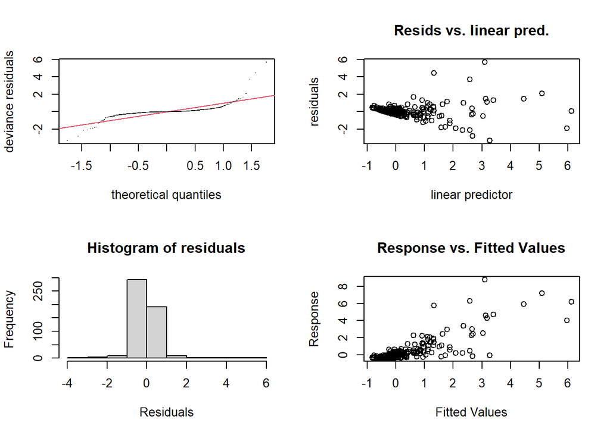

```
##
## Method: GCV   Optimizer: magic
## Smoothing parameter selection converged after 12 iterations.
## The RMS GCV score gradient at convergence was 1.874565e-07 .
## The Hessian was positive definite.
## Model rank =  28 / 28
##
## Basis dimension (k) checking results. Low p-value (k-index<1) may
## indicate that k is too low, especially if edf is close to k'.
##
##           k'  edf k-index p-value
## s(SS)   9.00 6.46    1.04    0.78
## s(PO4P) 9.00 8.22    1.09    0.96
## s(TC)   9.00 8.51    1.04    0.81
```

```r
par(mfrow=c(2,2))
gam.check(m2)
```

```r
par(mfrow=c(1,1))
```

### Time Varying Coefficient Model

#### scaling data 사용

```r
par(mar=c(4,4,4,4))
par(oma=c(0.5,0.5,0.5,0.5))
nrow(ex1_scale)
```

```
## [1] 510
```

```r
ex1_scale$time <- 1:nrow(ex1_scale)
head(ex1_scale)
```

```
##           pH          DO        BOD         COD          SS        TN        TP
## 1 -1.0559117  0.57712655  0.8679357 -0.09838260 -0.30463242 1.9455378 3.1348321
## 2  0.1030158  1.20396301 -0.3662108  0.06052516 -0.47291028 1.8745209 2.1873200
## 3  0.1030158  1.30843575  1.0442424  0.69615623 -0.34069196 0.9872702 0.9283878
## 4 -0.0901388  0.54230230  0.1039403  0.45779458 -0.08226525 1.0163226 1.4253347
## 5 -0.0901388 -0.01488566  2.1020822  1.45096812  0.54877672 1.8915834 1.9620374
## 6 -0.0901388  0.57712655 -0.1311353 -0.37647119 -0.36473165 0.8383191 1.5578539
##           TOC        WT        EC         TC      NH3N     PO4P       Chla
## 1  0.43585086 -1.513662 1.5150981  0.4709946 1.6626017 3.023745 -0.6749682
## 2  0.05735717 -1.513662 1.8286824 -0.1645721 1.5935727 2.584356 -0.5973607
## 3 -0.05078389 -1.513662 1.1920114  0.1000972 0.6403973 1.073473 -0.2391725
## 4  0.05735717 -1.263762 1.0684782  1.5288358 0.9596565 1.582240 -0.3525988
## 5  1.08469720 -1.138811 1.0969858  2.6389161 1.9421692 1.813497 -0.9824130
## 6 -0.37520705 -1.513662 0.2417561  0.3142774 0.3228640 1.936835 -1.1316581
##           FC       Flow       Rain time
## 1 -0.2363598 -0.3650946 -0.4053407    1
## 2 -0.3665071 -0.3587470 -0.5227168    2
## 3 -0.2914221 -0.3192120 -0.3368713    3
## 4 -0.2021544 -0.3384103 -0.3393166    4
## 5  0.5436901 -0.3201262 -0.4420207    5
## 6 -0.3640043 -0.3182978  0.4480813    6
```

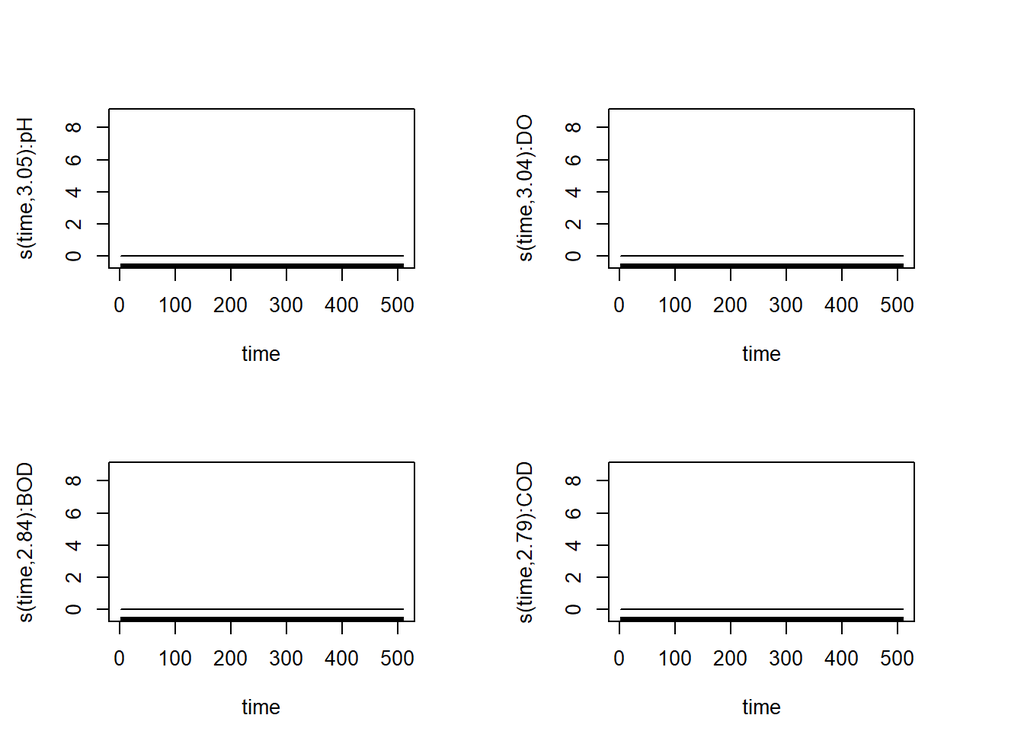

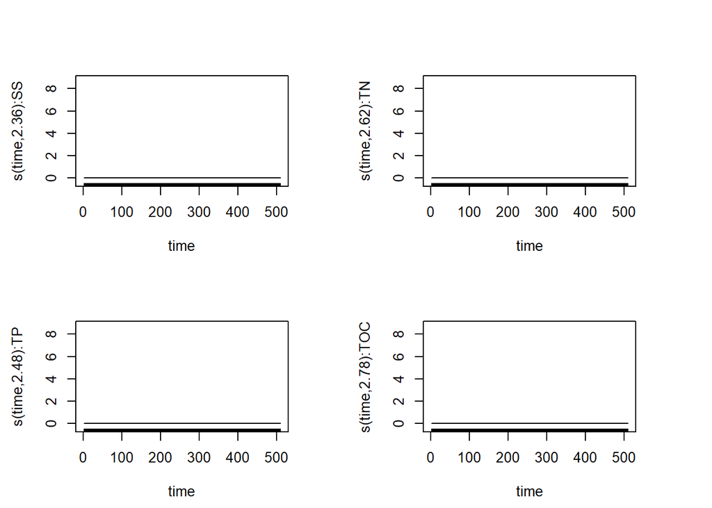

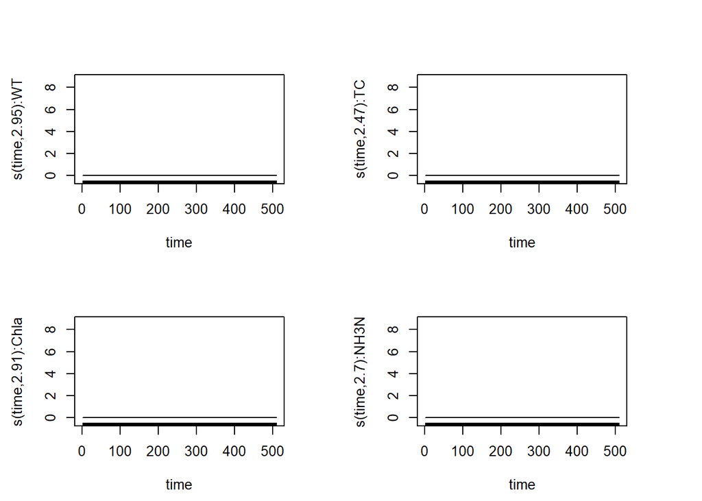

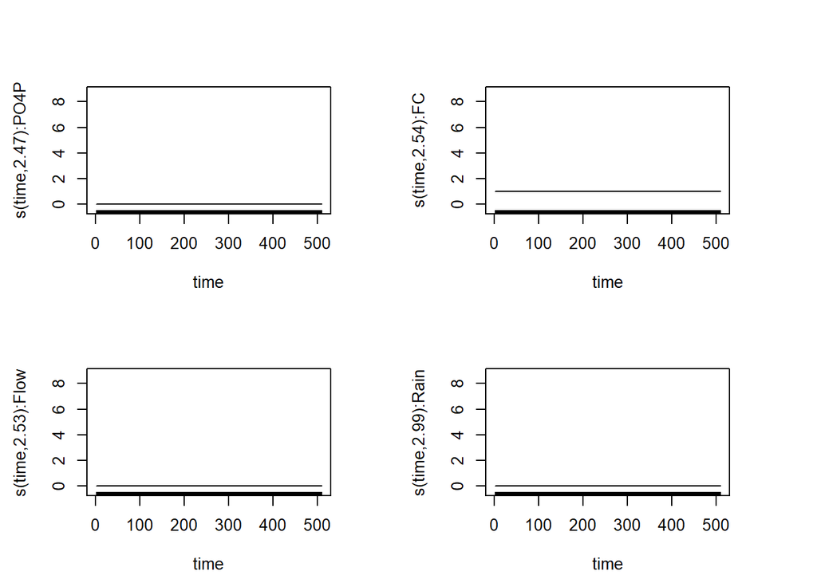

```r
vc1 <- gam(FC~s(time,by=pH)+s(time,by=DO)+s(time,by=BOD)+s(time,by=COD)+s(time,by=SS)+s(time,by=TN)+s(time,by=TP)+s(time,by=TOC)+s(time,by=WT)+s(time,by=TC)+s(time,by=Chla)+s(time,by=NH3N)+s(time,by=PO4P)+s(time,by=FC)+s(time,by=Flow)+s(time,by=Rain),data=ex1_scale)
par(mfrow=c(2,2))
plot(vc1,residuals=TRUE,pch=1,shade=TRUE,seWithMean=TRUE,shift=coef(vc1)[1])
```

```r
par(mfrow=c(1,1))
summary(vc1) # R-sq.(adj) =  1
```

```
##
## Family: gaussian
## Link function: identity
##
## Formula:
## FC ~ s(time, by = pH) + s(time, by = DO) + s(time, by = BOD) +
##     s(time, by = COD) + s(time, by = SS) + s(time, by = TN) +
##     s(time, by = TP) + s(time, by = TOC) + s(time, by = WT) +
##     s(time, by = TC) + s(time, by = Chla) + s(time, by = NH3N) +
##     s(time, by = PO4P) + s(time, by = FC) + s(time, by = Flow) +
##     s(time, by = Rain)
##
## Parametric coefficients:
##              Estimate Std. Error t value Pr(>|t|)
## (Intercept) 1.545e-17  3.432e-09       0        1
##
## Approximate significance of smooth terms:
##                edf Ref.df         F p-value
## s(time):pH   3.048  3.567 0.000e+00       1
## s(time):DO   3.039  3.527 0.000e+00       1
## s(time):BOD  2.841  3.264 0.000e+00       1
## s(time):COD  2.786  3.177 0.000e+00       1
## s(time):SS   2.362  2.610 0.000e+00       1
## s(time):TN   2.621  2.922 0.000e+00       1
## s(time):TP   2.477  2.736 0.000e+00       1
## s(time):TOC  2.780  3.179 0.000e+00       1
## s(time):WT   2.953  3.396 0.000e+00       1
## s(time):TC   2.468  2.741 0.000e+00       1
## s(time):Chla 2.914  3.367 0.000e+00       1
## s(time):NH3N 2.696  3.046 0.000e+00       1
## s(time):PO4P 2.472  2.724 0.000e+00       1
## s(time):FC   2.539  2.848 2.209e+16  <2e-16 ***
## s(time):Flow 2.526  2.844 0.000e+00       1
## s(time):Rain 2.993  3.473 0.000e+00       1
## ---
## Signif. codes:  0 '***' 0.001 '**' 0.01 '*' 0.05 '.' 0.1 ' ' 1
##
## R-sq.(adj) =      1   Deviance explained =  100%
## GCV = 1.8731e-15  Scale est. = 1.7096e-15  n = 510
```

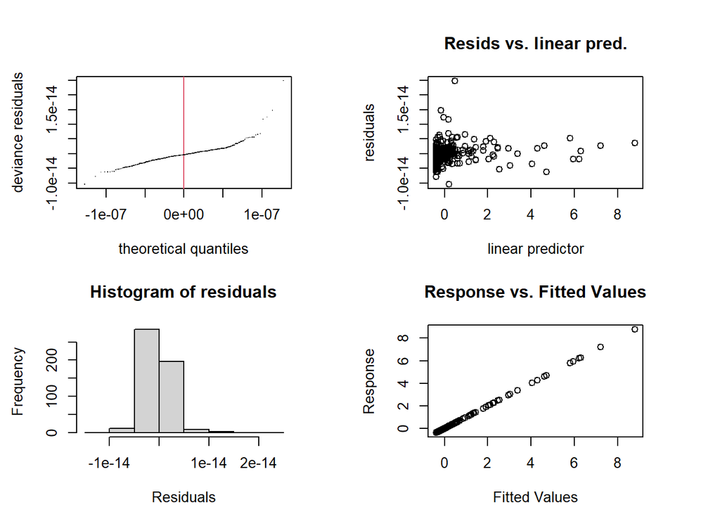

```
##
## Method: GCV   Optimizer: magic
## Smoothing parameter selection converged after 4 iterations by steepest
## descent step failure.
## The RMS GCV score gradient at convergence was 5.296976e-18 .
## The Hessian was not positive definite.
## Model rank =  161 / 161
##
## Basis dimension (k) checking results. Low p-value (k-index<1) may
## indicate that k is too low, especially if edf is close to k'.
##
##                 k'   edf k-index p-value
## s(time):pH   10.00  3.05    0.65  <2e-16 ***
## s(time):DO   10.00  3.04    0.65  <2e-16 ***
## s(time):BOD  10.00  2.84    0.65  <2e-16 ***
## s(time):COD  10.00  2.79    0.65  <2e-16 ***
## s(time):SS   10.00  2.36    0.65  <2e-16 ***
## s(time):TN   10.00  2.62    0.65  <2e-16 ***
## s(time):TP   10.00  2.48    0.65  <2e-16 ***
## s(time):TOC  10.00  2.78    0.65  <2e-16 ***
## s(time):WT   10.00  2.95    0.65  <2e-16 ***
## s(time):TC   10.00  2.47    0.65  <2e-16 ***
## s(time):Chla 10.00  2.91    0.65  <2e-16 ***
## s(time):NH3N 10.00  2.70    0.65  <2e-16 ***
## s(time):PO4P 10.00  2.47    0.65  <2e-16 ***
## s(time):FC   10.00  2.54    0.65  <2e-16 ***
## s(time):Flow 10.00  2.53    0.65  <2e-16 ***
## s(time):Rain 10.00  2.99    0.65  <2e-16 ***
## ---
## Signif. codes:  0 '***' 0.001 '**' 0.01 '*' 0.05 '.' 0.1 ' ' 1
```

```r
par(mfrow=c(2,2))
gam.check(vc1)
```

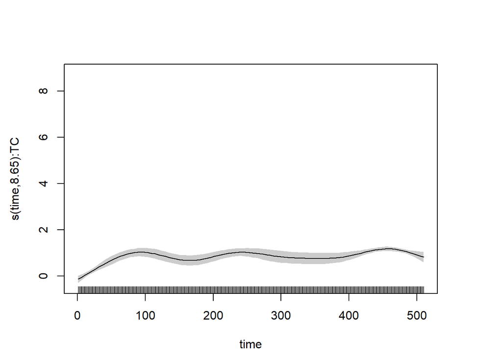

```r
par(mfrow=c(1,1))
vc2 <- gam(FC~s(time,by=TC),data=ex1_scale) # vc2 모형에서 유의하지 않다고 나온 변수 제외
plot(vc2,residuals=TRUE,pch=1,shade=TRUE,seWithMean=TRUE,shift=coef(vc2)[1])
```

```r
summary(vc2) # R-sq.(adj) =  0.766
```

```
##
## Family: gaussian
## Link function: identity
##
## Formula:
## FC ~ s(time, by = TC)
##
## Parametric coefficients:
##             Estimate Std. Error t value Pr(>|t|)
## (Intercept)  0.02807    0.02334   1.203     0.23
##
## Approximate significance of smooth terms:
##              edf Ref.df     F p-value
## s(time):TC 8.645   9.52 174.9  <2e-16 ***
## ---
## Signif. codes:  0 '***' 0.001 '**' 0.01 '*' 0.05 '.' 0.1 ' ' 1
##
## R-sq.(adj) =  0.766   Deviance explained =   77%
## GCV = 0.23895  Scale est. = 0.23444   n = 510
```

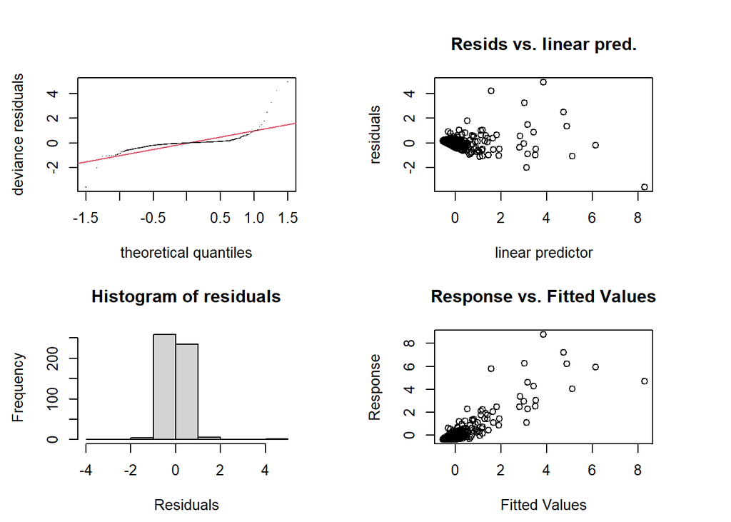

```
##
## Method: GCV   Optimizer: magic
## Smoothing parameter selection converged after 7 iterations.
## The RMS GCV score gradient at convergence was 3.557006e-06 .
## The Hessian was positive definite.
## Model rank =  11 / 11
##
## Basis dimension (k) checking results. Low p-value (k-index<1) may
## indicate that k is too low, especially if edf is close to k'.
##
##               k'   edf k-index p-value
## s(time):TC 10.00  8.65    0.83   0.005 **
## ---
## Signif. codes:  0 '***' 0.001 '**' 0.01 '*' 0.05 '.' 0.1 ' ' 1
```

```r
par(mfrow=c(2,2))
gam.check(vc2)
```

```r
par(mfrow=c(1,1))
```

#### 최종선택된 모형의 설명력 : 60.4%(다중선형회귀모형), 67.7%(일반화가법모형) , 76.6%(시간에 따른 계수변화모형)

#### 일반화가법모형이나 시간에 따른 계수변화모형이 다중선형회귀모형보다 설명력이 우수하다는 것을 확실하게 보여주기 위해서는 설명변수들과 확실한 비선형관계가 있다고 여겨지는 변수를 반응변수로 선택하는 것이 좋다고 판단됨.

### 사용데이터 : 우치 지점 데이터

#### 모니터링 기간 : 2010~2019년 (일별 주단위자료)

#### 반응변수 : TC 또는 FC

#### 설명변수 : pH, DO, BOD, COD, SS, TN, TP, TOC, WT, EC, NH3N, PO4P, Chla, Flow, Rain

#### 수질항목별 단위가 다르다는 점을 감안하여 표준화된 데이터를 사용

### Dependent(Response) variable : TC

### Multiple Linear Regression

#### scaling data 사용

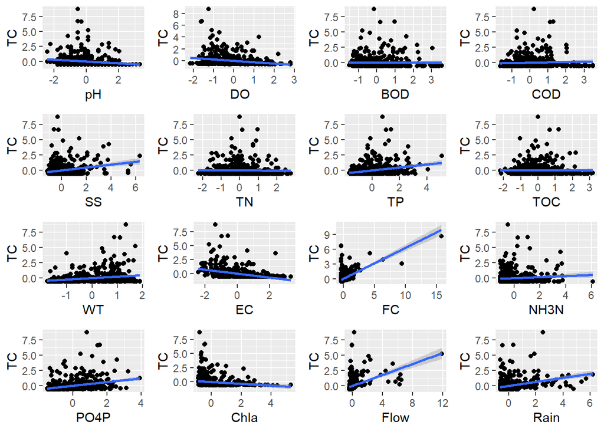

```r
ex2 <- read.csv("C:/Users/HSY/Desktop/우치(2010-2019).csv", sep=",", header=T)
ex2 <- ex2[,-1]
ex2_scale <- scale(ex2)
ex2_scale <- as.data.frame(ex2_scale)
g1 <- ggplot(data=ex2_scale,aes(x=pH,y=TC)) + geom_point() + stat_smooth(method=lm)
g2 <- ggplot(data=ex2_scale,aes(x=DO,y=TC)) + geom_point() + stat_smooth(method=lm)
g3 <- ggplot(data=ex2_scale,aes(x=BOD,y=TC)) + geom_point() + stat_smooth(method=lm)
g4 <- ggplot(data=ex2_scale,aes(x=COD,y=TC)) + geom_point() + stat_smooth(method=lm)
g5 <- ggplot(data=ex2_scale,aes(x=SS,y=TC)) + geom_point() + stat_smooth(method=lm)
g6 <- ggplot(data=ex2_scale,aes(x=TN,y=TC)) + geom_point() + stat_smooth(method=lm)
g7 <- ggplot(data=ex2_scale,aes(x=TP,y=TC)) + geom_point() + stat_smooth(method=lm)
g8 <- ggplot(data=ex2_scale,aes(x=TOC,y=TC)) + geom_point() + stat_smooth(method=lm)
g9 <- ggplot(data=ex2_scale,aes(x=WT,y=TC)) + geom_point() + stat_smooth(method=lm)
g10 <- ggplot(data=ex2_scale,aes(x=EC,y=TC)) + geom_point() + stat_smooth(method=lm)
g11 <- ggplot(data=ex2_scale,aes(x=FC,y=TC)) + geom_point() + stat_smooth(method=lm)
g12 <- ggplot(data=ex2_scale,aes(x=NH3N,y=TC)) + geom_point() + stat_smooth(method=lm)
g13 <- ggplot(data=ex2_scale,aes(x=PO4P,y=TC)) + geom_point() + stat_smooth(method=lm)
g14 <- ggplot(data=ex2_scale,aes(x=Chla,y=TC)) + geom_point() + stat_smooth(method=lm)
g15 <- ggplot(data=ex2_scale,aes(x=Flow,y=TC)) + geom_point() + stat_smooth(method=lm)
g16 <- ggplot(data=ex2_scale,aes(x=Rain,y=TC)) + geom_point() + stat_smooth(method=lm)
grid.arrange(g1,g2,g3,g4,g5,g6,g7,g8,g9,g10,g11,g12,g13,g14,g15,g16,nrow=4,ncol=4)
```

```r
gfit <- lm(TC~.,data=ex2_scale)
summary(gfit) # Adjusted R-squared:  0.4856
```

```
##
## Call:
## lm(formula = TC ~ ., data = ex2_scale)
##
## Residuals:
##     Min      1Q  Median      3Q     Max
## -1.7810 -0.2875 -0.1304  0.0929  6.4383
##
## Coefficients:
##               Estimate Std. Error t value Pr(>|t|)
## (Intercept)  2.719e-17  3.173e-02   0.000  1.00000
## pH          -2.142e-02  4.041e-02  -0.530  0.59622
## DO          -9.665e-02  6.009e-02  -1.608  0.10840
## BOD          9.820e-02  6.782e-02   1.448  0.14823
## COD         -6.543e-03  8.158e-02  -0.080  0.93611
## SS          -9.125e-02  5.358e-02  -1.703  0.08921 .
## TN           1.936e-02  5.355e-02   0.362  0.71780
## TP           8.812e-02  5.678e-02   1.552  0.12135
## TOC          2.118e-03  7.419e-02   0.029  0.97723
## WT          -9.036e-02  7.695e-02  -1.174  0.24082
## EC          -1.237e-01  4.627e-02  -2.673  0.00777 **
## NH3N        -1.910e-04  4.066e-02  -0.005  0.99625
## PO4P         2.363e-02  5.470e-02   0.432  0.66592
## Chla        -2.911e-02  5.926e-02  -0.491  0.62350
## FC           5.229e-01  3.419e-02  15.292  < 2e-16 ***
## Flow         2.719e-01  4.256e-02   6.389 3.87e-10 ***
## Rain        -3.186e-02  4.463e-02  -0.714  0.47567
## ---
## Signif. codes:  0 '***' 0.001 '**' 0.01 '*' 0.05 '.' 0.1 ' ' 1
##
## Residual standard error: 0.7172 on 494 degrees of freedom
## Multiple R-squared:  0.5017, Adjusted R-squared:  0.4856
## F-statistic: 31.09 on 16 and 494 DF,  p-value: < 2.2e-16
```

```r
vif(gfit)
```

```
##       pH       DO      BOD      COD       SS       TN       TP      TOC
## 1.618797 3.580305 4.559829 6.598958 2.846806 2.843162 3.196860 5.457251
##       WT       EC     NH3N     PO4P     Chla       FC     Flow     Rain
## 5.870219 2.122555 1.639454 2.966673 3.482288 1.159259 1.796005 1.974570
```

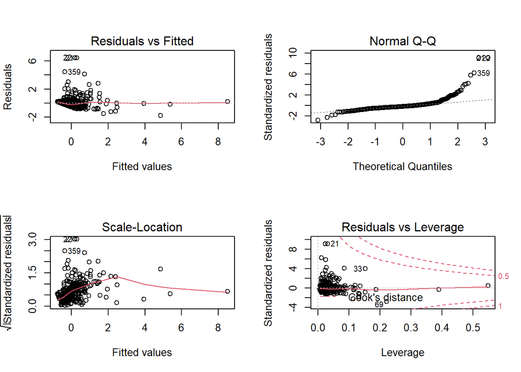

```r
par(mfrow=c(2,2))
plot(gfit)
```